# Intro to R and Basic Features

2025-02-11

## Welcome R user

- **R** is a programming language designed for:
  - Statistical computing
  - Data analysis
  - Visualization

## Origin

- R comenzó a ser desarrollado en 1992 por Robert Gentleman y Ross Ihaka, de departamento de Estadística de la Universidad de Auckland (Nueva Zelanda), con el objetivo de disponer de un lenguaje para enseñar cursos introductorios de estadística.
- La primera versión del programa sale en 1994; en 1995 adopta una licencia de software libre GNU. La difusión del programa se realiza boca a boca.

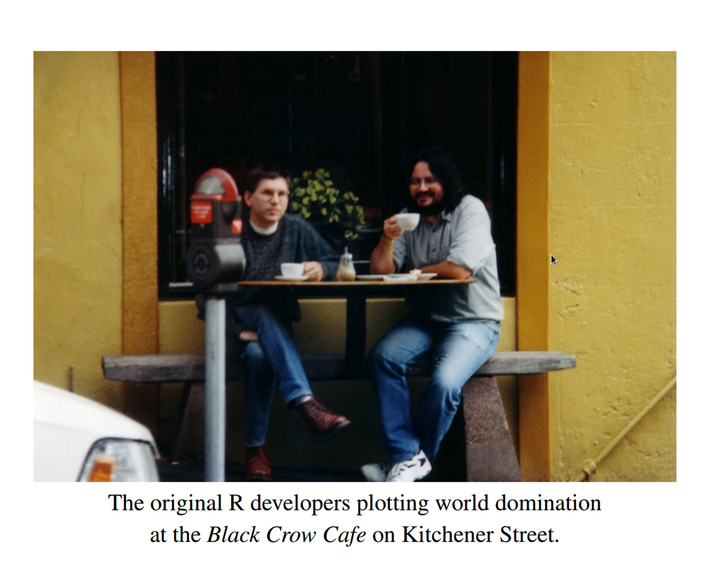

- En 1996 publican en el Journal of Computational and Graphical Statistics un artículo describiendo el programa: [R: A language for data analysis and graphics](http://www.aliquote.org/cours/2012_biomed/biblio/Ihaka1996.pdf)

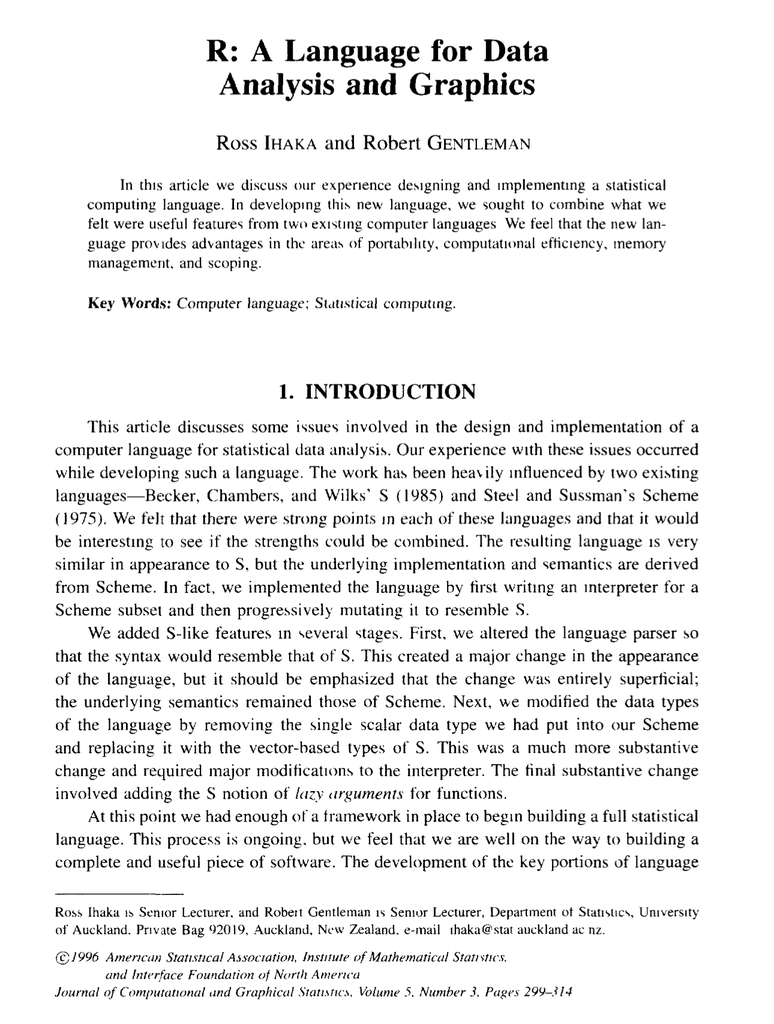

## ¿Why learn R?

is just this

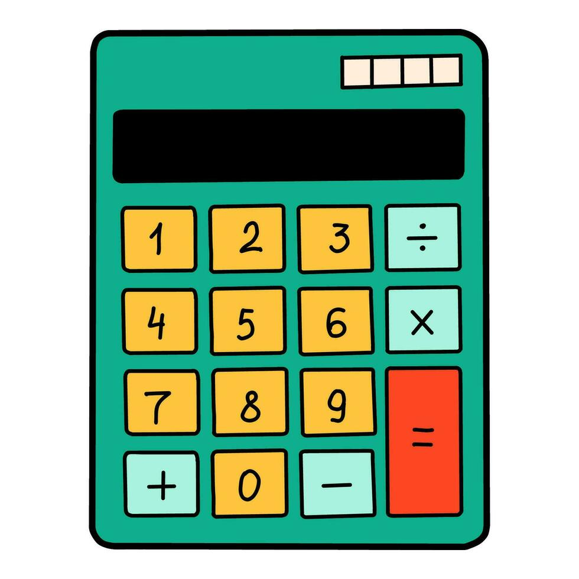

but… powerfull!

- Open source and free
- big community
- ~ 13.000 packages
- Reproducible science

## Getting Started

Install R from [CRAN](https://cran.r-project.org)

[figure not shown]

[Download R](https://www.r-project.org)

Install RStudio (optional, but highly recommended)

[figure not shown]

[Download Rstudio](https://posit.co/download/rstudio-desktop/)

Write your first R command:

```r
print("Hello, world!")
```

```
## [1] "Hello, world!"
```

## Basic Data Types

- **Numeric:** Numbers (e.g., `3.14`, `42`)
- **Character:** Text strings (e.g., `"fish"`)
- **Logical:** `TRUE` or `FALSE`
- **Factor:** Categorical variables

## Vectors

- R’s most fundamental data structure:

```r
numbers <- c(1, 2, 3, 4)
letters <- c("a", "b", "c")
```

- Operations are vectorized:

```r
numbers * 2
```

```
## [1] 2 4 6 8
```

## Data Frames

- Table-like structures:

```r
df <- data.frame(Name = c("John", "Jane"), Age = c(25, 30))
```

- Inspect the structure:

```r
head(df)
```

```
##   Name Age
## 1 John  25
## 2 Jane  30
```

## Visualization

Data used

```r
head(iris)
```

```
##   Sepal.Length Sepal.Width Petal.Length Petal.Width Species
## 1          5.1         3.5          1.4         0.2  setosa
## 2          4.9         3.0          1.4         0.2  setosa
## 3          4.7         3.2          1.3         0.2  setosa
## 4          4.6         3.1          1.5         0.2  setosa
## 5          5.0         3.6          1.4         0.2  setosa
## 6          5.4         3.9          1.7         0.4  setosa
```

Structure

```r
str(iris)
```

```
## 'data.frame':    150 obs. of  5 variables:
##  $ Sepal.Length: num  5.1 4.9 4.7 4.6 5 5.4 4.6 5 4.4 4.9 ...
##  $ Sepal.Width : num  3.5 3 3.2 3.1 3.6 3.9 3.4 3.4 2.9 3.1 ...
##  $ Petal.Length: num  1.4 1.4 1.3 1.5 1.4 1.7 1.4 1.5 1.4 1.5 ...
##  $ Petal.Width : num  0.2 0.2 0.2 0.2 0.2 0.4 0.3 0.2 0.2 0.1 ...
##  $ Species     : Factor w/ 3 levels "setosa","versicolor",..: 1 1 1 1 1 1 1 1 1 1 ...
```

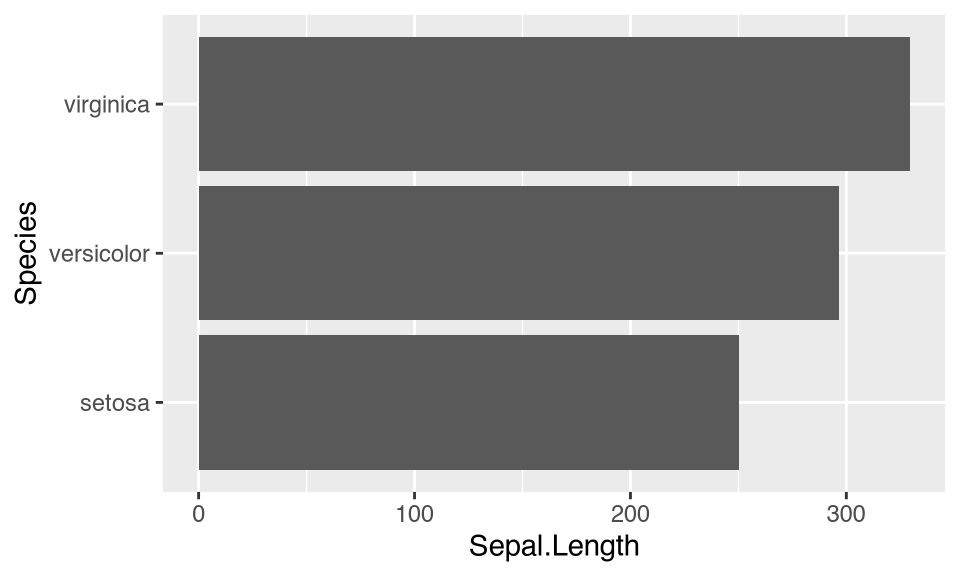

```r
plottex <- ggplot(iris,
       aes(x = Sepal.Length,
           y = Species)) +
  geom_bar(stat = "identity")
plottex
```

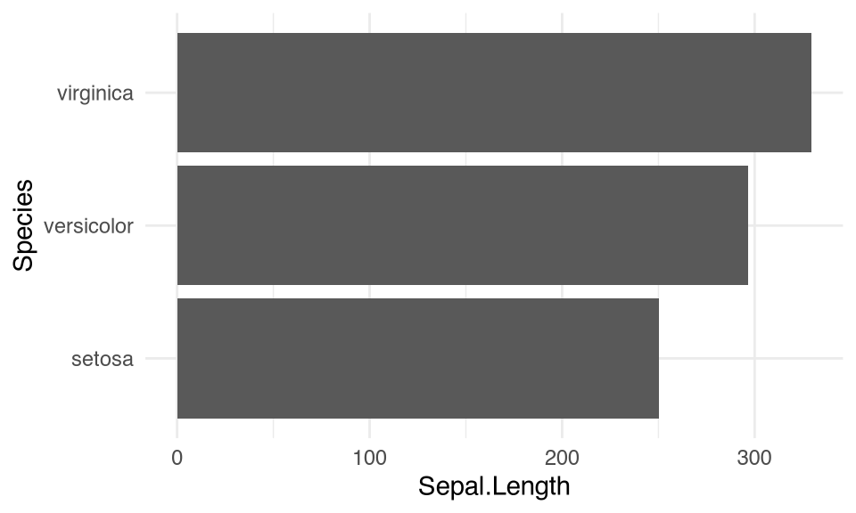

```r
plottex <- ggplot(iris,
       aes(x = Sepal.Length,
           y = Species)) +
  geom_bar(stat = "identity")+
  theme_minimal()
plottex
```

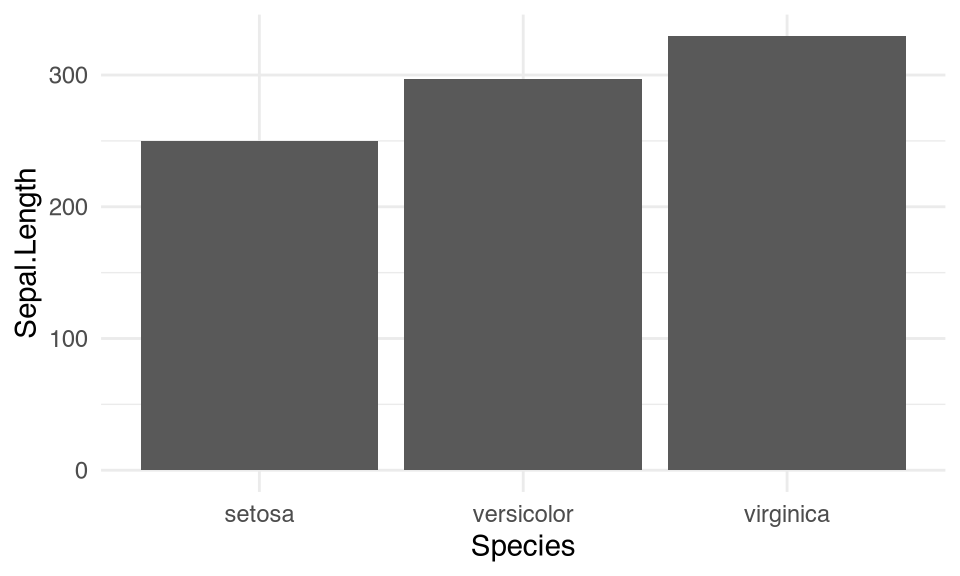

```r
plottex <- ggplot(iris,
       aes(x = Sepal.Length,
           y = Species)) +
  geom_bar(stat = "identity")+
  theme_minimal()+
  coord_flip()
plottex
```

## Functions

- Encapsulate reusable logic:

```r
square <- function(x) {
     return(x^2)
   }
square(4)  # Output: 16
```

```
## [1] 16
```

## Statistical Analysis

- Linear regression example:

```r
fit <- lm(mpg ~ wt, data = mtcars)
summary(fit)
```

```
##
## Call:
## lm(formula = mpg ~ wt, data = mtcars)
##
## Residuals:
##     Min      1Q  Median      3Q     Max
## -4.5432 -2.3647 -0.1252  1.4096  6.8727
##
## Coefficients:
##             Estimate Std. Error t value Pr(>|t|)
## (Intercept)  37.2851     1.8776  19.858  < 2e-16 ***
## wt           -5.3445     0.5591  -9.559 1.29e-10 ***
## ---
## Signif. codes:  0 '***' 0.001 '**' 0.01 '*' 0.05 '.' 0.1 ' ' 1
##
## Residual standard error: 3.046 on 30 degrees of freedom
## Multiple R-squared:  0.7528, Adjusted R-squared:  0.7446
## F-statistic: 91.38 on 1 and 30 DF,  p-value: 1.294e-10
```

## Write on a *“Script”*

[figure not shown]

## Conclusion

- R is powerful for:
  - Data analysis
  - Visualization
  - Statistics
  - **Powerful tool in Earth sciences!**